```python
# import required libraries for project wrangle_act

import pandas as pd
import numpy as np
import requests
import tweepy
import json
import re
import matplotlib.pyplot as plt
import warnings
import os
import time
import seaborn as sns
```

# Gather WeRateDogs Analysis and Visulization Report

Submitted by Doug Olsen

1 Rating Ratio Analysis over Time

2 Favorites vs. ReTweets Scatter Plot

3 Descriptive Statistics Analysis

4 Problems Encountered in Gathering Phase

```python
# Read in master csv file as a Pandas DataFrame fro analysis
twitter_archive_clean = pd.read_csv('twitter_archive_master.csv', index_col = 0)
```

```python
twitter_archive_clean.info()
```

```
<class 'pandas.core.frame.DataFrame'>
Int64Index: 1459 entries, 1 to 2068
Data columns (total 22 columns):
tweet_id              1459 non-null int64
timestamp             1459 non-null object
source                1459 non-null object
text                  1459 non-null object
expanded_urls         1459 non-null object
rating_numerator      1459 non-null int64
rating_denominator    1459 non-null int64
name                  1459 non-null object
dog_stage             231 non-null object
favorites             1459 non-null int64
retweets              1459 non-null int64
jpg_url               1459 non-null object
img_num               1459 non-null int64
p1                    1459 non-null object
p1_conf               1459 non-null float64
p1_dog                1459 non-null bool
p2                    1459 non-null object
p2_conf               1459 non-null float64
p2_dog                1459 non-null bool
p3                    1459 non-null object
p3_conf               1459 non-null float64
p3_dog                1459 non-null bool
dtypes: bool(3), float64(3), int64(6), object(10)
memory usage: 232.2+ KB
```

```python
# timestamp is string , it should be converted to datetime
twitter_archive_clean['timestamp'] = pd.to_datetime(twitter_archive_clean['timestamp'])
```

```python
twitter_archive_clean.info()
```

```
<class 'pandas.core.frame.DataFrame'>
Int64Index: 1459 entries, 1 to 2068
Data columns (total 22 columns):
tweet_id              1459 non-null int64
timestamp             1459 non-null datetime64[ns]
source                1459 non-null object
text                  1459 non-null object
expanded_urls         1459 non-null object
rating_numerator      1459 non-null int64
rating_denominator    1459 non-null int64
name                  1459 non-null object
dog_stage             231 non-null object
favorites             1459 non-null int64
retweets              1459 non-null int64
jpg_url               1459 non-null object
img_num               1459 non-null int64
p1                    1459 non-null object
p1_conf               1459 non-null float64
p1_dog                1459 non-null bool
p2                    1459 non-null object
p2_conf               1459 non-null float64
p2_dog                1459 non-null bool
p3                    1459 non-null object
p3_conf               1459 non-null float64
p3_dog                1459 non-null bool
dtypes: bool(3), datetime64[ns](1), float64(3), int64(6), object(9)
memory usage: 232.2+ KB
```

```python
# Create rating_ratio variable by dividing the rating numerator by the deonominator:

twitter_archive_clean['rating_ratio'] = twitter_archive_clean['rating_numerator']/twitter_archive_clean['rating_denominator']
```

### Analyze and Create Visualization

```python
twitter_archive_clean['rating_ratio'].value_counts()
```

```
1.2    380
1.0    318
1.1    307
1.3    214
0.9    107
0.8     58
0.7     24
1.4     21
0.6     12
0.5     10
0.4      4
0.3      3
0.2      1
Name: rating_ratio, dtype: int64
```

[figure not shown]

```python
# Set the index to be the timestamp so time is displayed properly in plots
twitter_archive_clean.set_index('timestamp', inplace=True)

twitter_archive_clean['rating_ratio'].plot(color = 'green')
plt.style.use('seaborn-darkgrid')
plt.xlabel('Date')
plt.ylabel('Rating Ratio')
plt.title('Dog Rating Ratio 12/2015 thru 8/2018')
plt.savefig('ratio.png')
plt.show()
```

### Dog Rating Ratio over Time

```
*Eliminated all observations for ratings that did not make sense:
    *rating_denominator != 10
    *rating_numerator > 20
```

Created a ratio called 'rating_ratio' and plotted the trend over the period that the twitter data was archived from 12/2015 through 8/2017.

Ratings have tended to increase over time "grade inflation" , in fact by the last month the rating ratio was over 1.2 which translates to a ratig of 12/10.

I guess this is a fun site so it is hard to make any real sense out of this other than people love thier dogs, and advertisers should taget these folks since the might have a high propensity to spend a lot on thier dogs.

```
Text(0.5,1,'Favorites vs. Retweets Scatter plot')
```

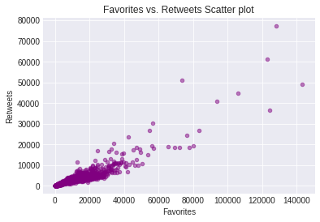

```python
twitter_archive_clean.plot(kind = 'scatter', x = 'favorites', y = 'retweets', alpha = 0.5, color = 'purple')
plt.xlabel('Favorites')
plt.ylabel('Retweets')
plt.title('Favorites vs. Retweets Scatter plot')
```

### Favorites vs. Retweets Scatter plot

As expected the retweets are positivly correlated with the favorites. There are a number of Outliers on this plot and if I had more time i would be curious to investigte why some images are so well liked and shared.

```python
twitter_archive_clean.describe()
```

|  | tweet_id | rating_numerator | rating_denominator | favorites | retweets | img_num | p1_conf | p2_conf | p3_conf | rating_ratio |
| --- | --- | --- | --- | --- | --- | --- | --- | --- | --- | --- |
| count | 1.459000e+03 | 1459.000000 | 1459.0 | 1459.000000 | 1459.000000 | 1459.000000 | 1459.000000 | 1459.000000 | 1.459000e+03 | 1459.000000 |
| mean | 7.408522e+17 | 10.923235 | 10.0 | 9229.684716 | 2735.447567 | 1.213845 | 0.613936 | 0.141455 | 6.160172e-02 | 1.092324 |
| std | 6.882306e+16 | 1.696725 | 0.0 | 12892.856116 | 4763.757739 | 0.575733 | 0.260357 | 0.102625 | 5.248928e-02 | 0.169673 |
| min | 6.660209e+17 | 2.000000 | 10.0 | 79.000000 | 13.000000 | 1.000000 | 0.044333 | 0.000023 | 2.160900e-07 | 0.200000 |
| 25% | 6.779068e+17 | 10.000000 | 10.0 | 2157.500000 | 637.500000 | 1.000000 | 0.390492 | 0.057042 | 1.511240e-02 | 1.000000 |
| 50% | 7.153425e+17 | 11.000000 | 10.0 | 4450.000000 | 1403.000000 | 1.000000 | 0.615678 | 0.127998 | 4.981050e-02 | 1.100000 |
| 75% | 7.960558e+17 | 12.000000 | 10.0 | 11557.000000 | 3172.500000 | 1.000000 | 0.849540 | 0.204031 | 9.509875e-02 | 1.200000 |
| max | 8.921774e+17 | 14.000000 | 10.0 | 143496.000000 | 77411.000000 | 4.000000 | 0.999956 | 0.467678 | 2.710420e-01 | 1.400000 |

### Descriptive Statistics

- Evaluating the descriptive statistics for rating numerator/denominator by removing all the "fake" ratings we see that the after cleaning mean rating is ~ 11 , the max rating is 14 and the min rating is 2.
- Before wrangling the mean rating is 13 , the max rating is 1776 and the min rating is 0.
- The p1_confidance is 61% likelihood that the image is a dog, this is improved before the cleaning process where it was 59% this was not as dramatic.

### Problems Encountered in Gathering Phase

I found the Twitter API part very time consuming and frustrating, i downloaded twitter-archive-enhanced.csv into microsoft excel before uploading the file into Jupyter notebook, this caused a bug in my program. Took 2 days to fix.Excel wass the root cause , when i downloaded and uploded the .csv file directly into Jupyter Notebook bug fixed.

For me the gathering phase was the most time consuming and difficult part of the project.